# TREINAMENTOSEPARAÇÃO

**SEPARAÇÃO**

No campo **Código** digite o numero da sua matricula e clique em **Entrar.**

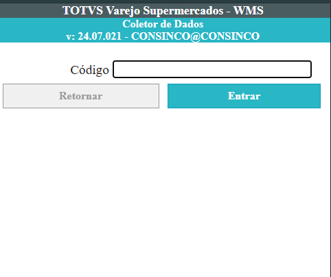

- Clicar em **Busca Tarefa** para iniciar a Separação.

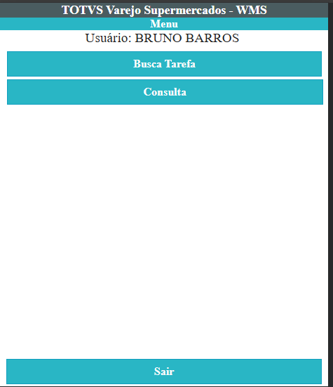

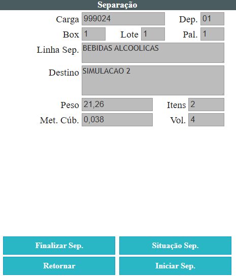

- Em endereço, será informado o apanha que se deve direcionar para inicar a separação do produto

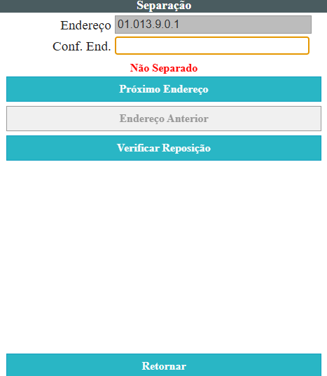

- Com o coletor, bipar na etiqueta do endereço colada na longarina, caso não reconheça ou apareça algum erro no coletor, digitar manualmente o código do endereço, presente abaixo do código de barras.

[figure not shown]

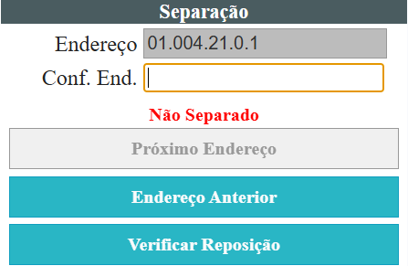

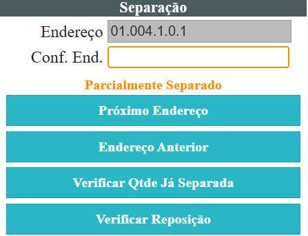

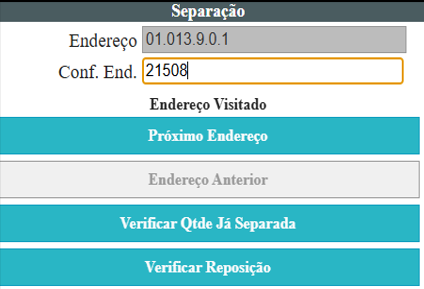

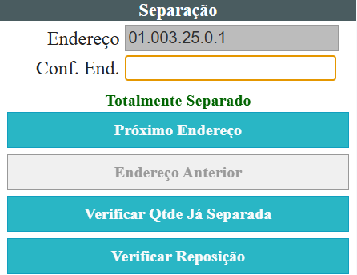

Obs.: O código do endereço irá aparecer (21508) no Campo **Conf. End.**

- Nesta tela, será possível identificar a Descrição do Produto, que consta no endereço.
- Em **Separar**, é possível verificar a quantidade que deve ser separada.

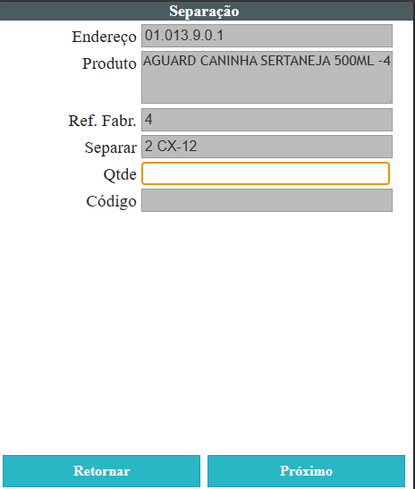

- Em QTDE digitar a quantidade de caixas.

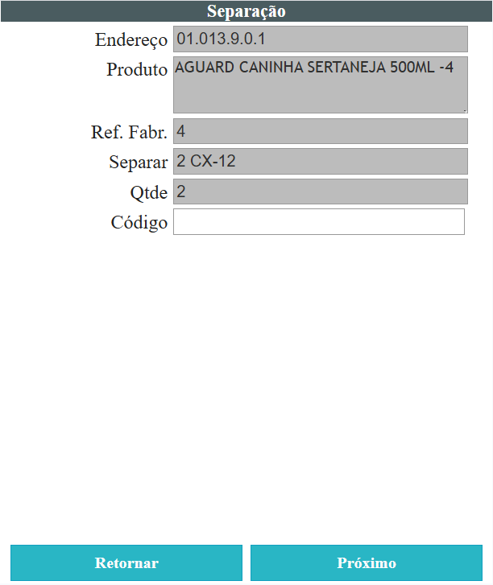

- Caso seja informada a quantidade acima do pedido solicitado, será mostrado uma janela com informativo de erro.

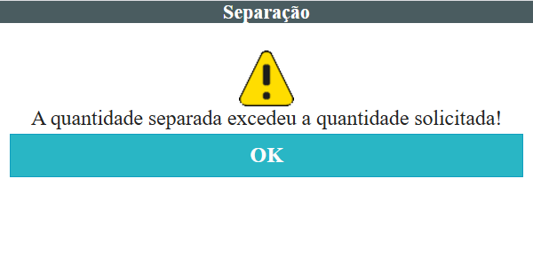

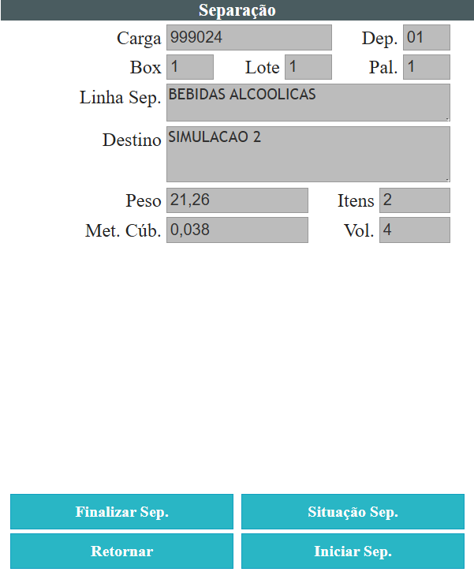

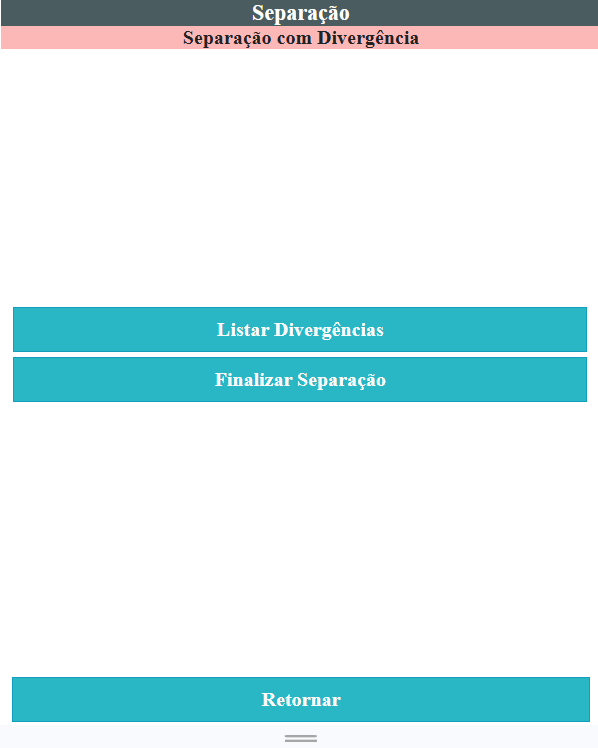

- Caso queira listar as divergências para consulta ou para corrigir a pendência da separação clique em **Listas Divergências.**

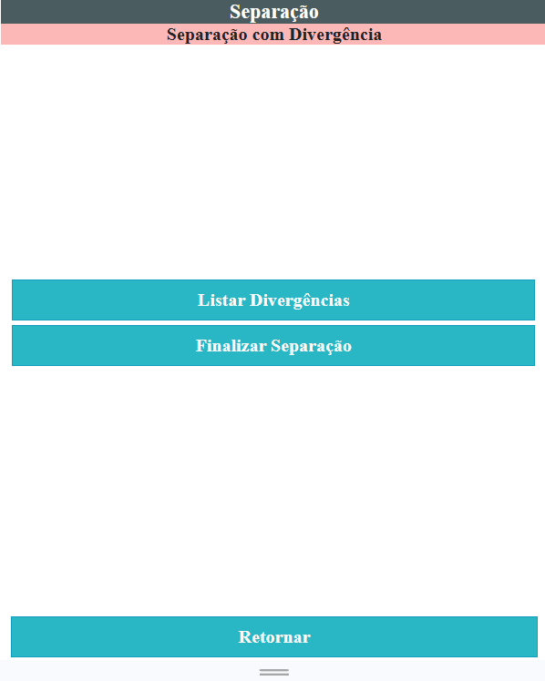

- Na hipótese de ter localizafo o produto, aparecerá a seguinte tela pedindo para informar a quantidade total, ou seja, o sistema não contabilizará a quantidade que ja foi separada, apenas solicitará uma nova contagem, sendo assim deve-se informar a quantiadade total do produto que foi separado.

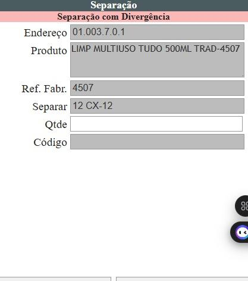

- Na próxima tela em Qtde digite a quantidade de caixas e no campo Código bipe na caixa, logo após clique em Finalizar Sep.

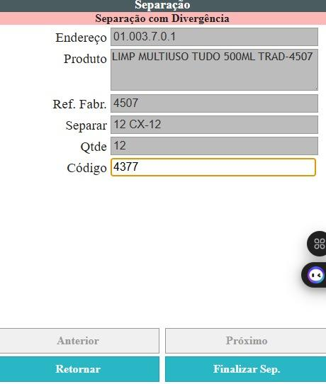

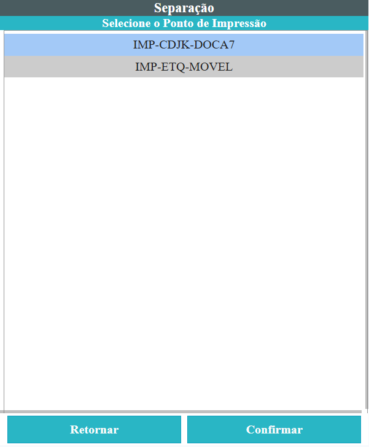

[figure not shown]

- Após confirmar, o sistema irá abrir a tela abaixo, indicando que a separação foi concluída. Após, retirar a etiqueta impressa, bipar no código de barra, para confirmar a finalização da separação, logo após conduzir o palete separado com a etiqueta para a doca.
- OBS: A SEPARAÇÃO SERÁ **FINALIZADA APENAS APÓS A IMPRESSAO E CONFIRMAÇÃO DA ETIQUETA**, NO QUAL O LOTE SOMENTE PODERÁ SER RECONFERIDO, CARREGADO E FATURADO PELA A ETIQUETA ANEXADA NO PALETE.

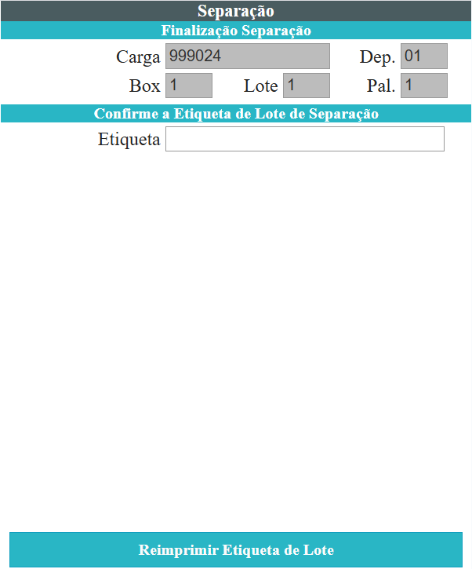

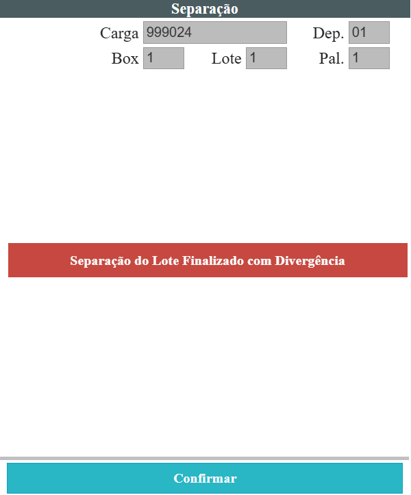

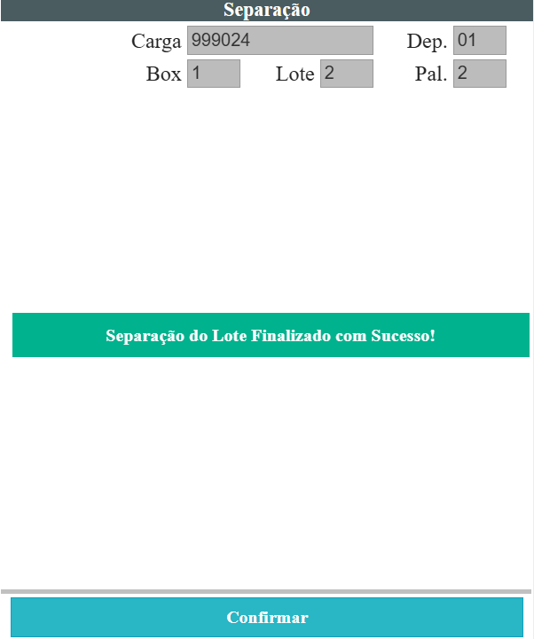

[figure not shown]

[figure not shown]